# Using R for Analytic Graphs: Learn How Data Visualization Can Improve Interpretation in Social Work Research

Joseph Mienko, David Rothwell, Richard Smith, & Gregor Thomas

Saturday, January 18, 2015

# Why Use R?

- Free
- Open Source
- Easy Collaboration
- Replicable Research
- Effective Statistical Communication
- Graphing Capabilities

# Why Wouldn’t You Use R?

Steep(er) learning curve compared to, say, Excel or SPSS. This matters a lot if

- You run statistics rarely.
- You want a point and click interface.
- Restricted use data centers without R.
- Latent variable models (at least complex models (e.g. latent growth curves, latent class analysis, multilevel latent variable models)).

# Where Can you Get R?

- CRAN
- Our Thumb Drives

# Where Are We Going Today?

- Graphing Descriptive Statistics
- Graphing Model Results

# Graphing Descriptive Statistics

## Means and standard deviations

Excerpt from

Holland, D. E., Mistiaen, P., Knafl, G. J., & Bowles, K. H. (2011). The English translation and testing of the problems after discharge questionnaire. *Social Work Research*, 35(2), 107–116.

## What we see in the journal article…

| Subscale and Range | Abbreviated item and Content | M(+-SD) | Item-total correlation |
| --- | --- | --- | --- |
| Household Activities | Prepare food | 1.60(1.00) | 0.72 |
|  | Grocery shop | 2.97(1.80) | 0.78 |
|  | Clean house | 2.78(1.70) | 0.82 |
|  | Laundry | 2.25(1.60) | 0.83 |
|  | Change bed linen | 2.75(1.70) | 0.83 |
|  | Wash dishes | 1.80(1.30) | 0.72 |
|  | Tidy living area | 1.57(1.20) | 0.74 |

# Graphing Descriptive Statistics

## What we could see in the journal article…

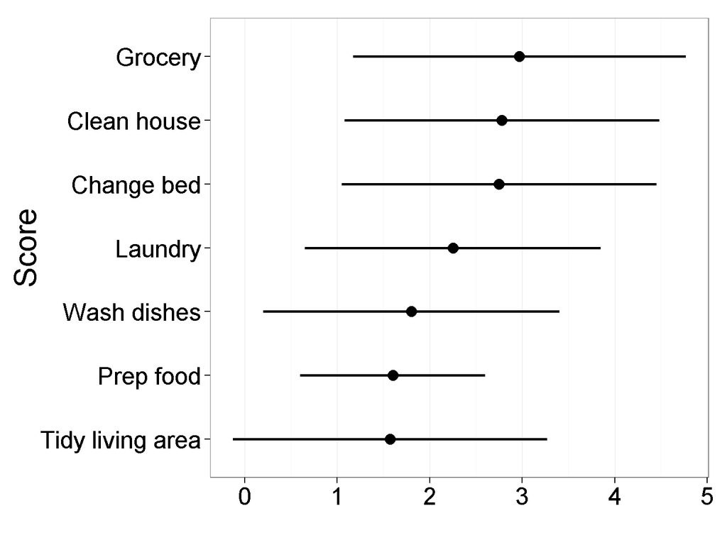

# Graphing Descriptive Statistics

## Bi-variate categorical data

Excerpt from

Trocme, N., Knoke, D., & Blackstock, C. (2004). Pathways to the overrepresentation of Aboriginal children in Canada’s child welfare system. *Social Service Review*, 78(4), 577–600.

# Graphing Descriptive Statistics

## What we see in the journal article…

| Placement status | Aboriginal (%) | Caucasian (%) |
| --- | --- | --- |
| Child welfare placement | 9.90 | 4.6 |
| Informal placement | 11.20 | 3.4 |
| Placement considered | 3.90 | 2.4 |
| No placement required | 75.10 | 89.6 |
| N | 831.00 | 3,563 |

# Graphing Descriptive Statistics

## What we could see in the journal article…

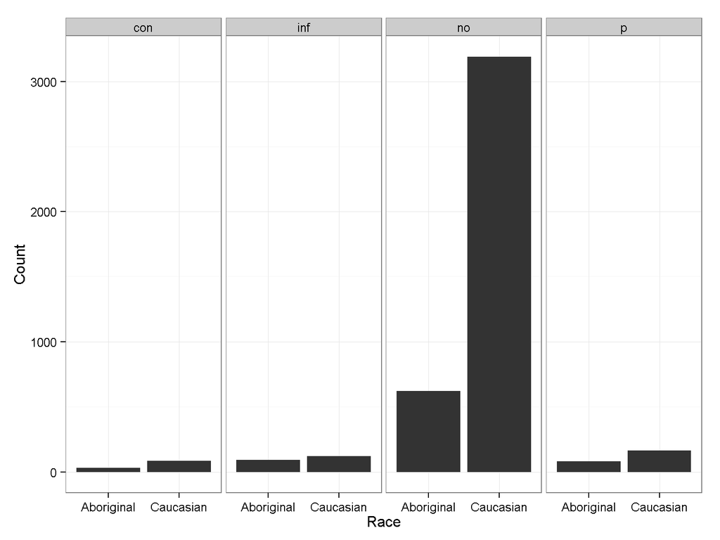

# Graphing Descriptive Statistics

## What we could see in the journal article…

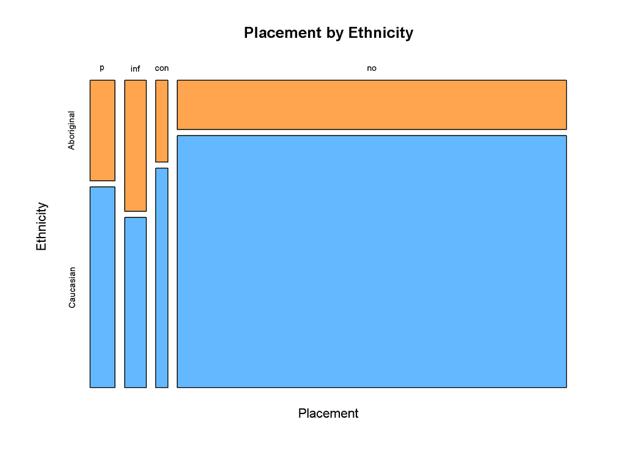

# Graphing Model Results

## Single regression model

Excerpt from

Trocme, N., Knoke, D., & Blackstock, C. (2004). Pathways to the overrepresentation of Aboriginal children in Canada’s child welfare system. *Social Service Review*, 78(4), 577–600.

# Graphing Model Results

## What we see in the journal article…

| Variable | Coefficient | OR | pvalue |
| --- | --- | --- | --- |
| Aboriginal(Caucasian) | 0.07 | 1.08 | 0.74 |
| Part-time(full-time) | 0.61 | 1.85 | 0.04 |
| Benefits(full-time) | 0.27 | 1.31 | 0.30 |
| Other income(full-time) | -0.86 | 0.42 | 0.14 |
| Unsafe housing | 0.53 | 1.70 | 0.07 |
| One move(no moves) | 0.42 | 1.52 | 0.06 |
| Two moves(no moves) | 1.12 | 3.06 | 0.00 |
| Two parent blend(two parent bio) | 0.58 | 1.79 | 0.05 |
| Single parent(two parent bio) | 0.73 | 2.08 | 0.00 |
| Previous case | 0.19 | 1.21 | 0.34 |
| Sexual abuse(physical abuse) | -0.80 | 0.45 | 0.05 |
| Neglect(physical abuse) | -0.24 | 0.78 | 0.26 |
| Emotional(physical abuse) | -0.64 | 0.53 | 0.06 |
| Domestic violence | -1.42 | 0.24 | 0.00 |
| Child sub abuse | 0.07 | 1.08 | 0.84 |
| One child beh(none) | 0.47 | 1.60 | 0.70 |
| Two more beh(none) | 1.22 | 3.38 | 0.00 |
| Age 4-7(0-3) | -0.52 | 0.59 | 0.06 |
| Age 8-11((0-3) | -0.32 | 0.72 | 0.28 |
| Age 12-15(0-3) | -0.12 | 0.88 | 0.71 |
| Parent age 31-40(&lt 30) | 0.37 | 1.44 | 0.12 |
| Parent age 41-50(&lt 30) | 0.44 | 1.55 | 0.21 |
| Parent age 50more(&lt 30) | 0.88 | 2.41 | 0.32 |
| Parent drug | -0.14 | 0.87 | 0.59 |
| Parent criminal | 0.57 | 1.77 | 0.02 |
| Parent cognitive | 0.89 | 2.44 | 0.00 |
| Few social support | 0.33 | 1.39 | 0.07 |
| Caregiver maltx | 0.40 | 1.49 | 0.04 |
| Parent alcohol | 0.43 | 1.54 | 0.05 |

# Graphing Model Results

## What we could see in the journal article…

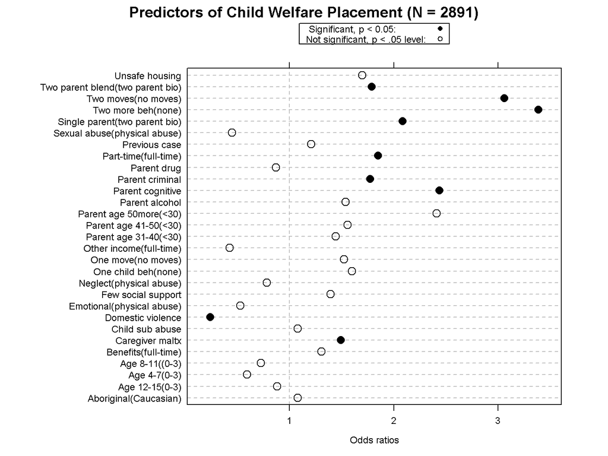

# Graphing Model Results

## What we could see in the journal article…

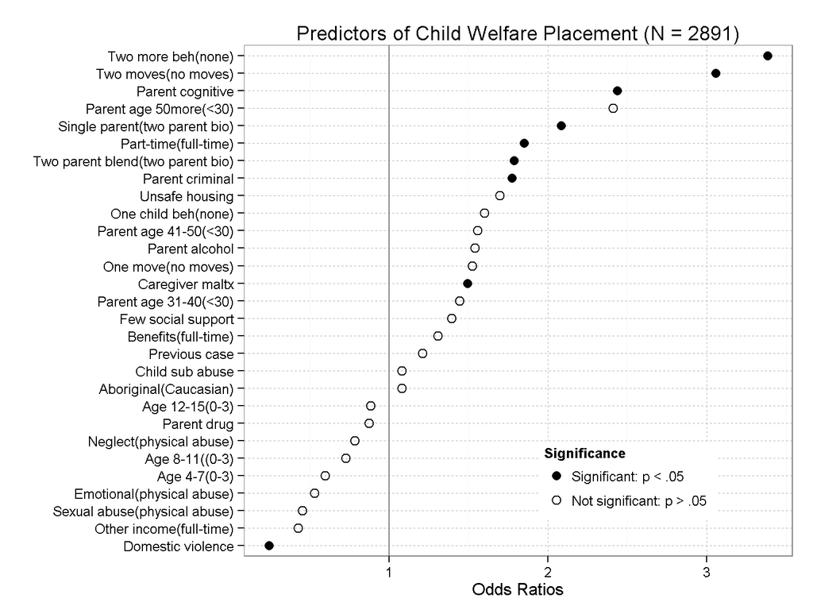

# Graphing Model Results

## Multiple regression models

Excerpt from

Shiovitz-Ezra, S., & Leitsch, S. A. (2010). The role of social relationships in predicting loneliness: The national social life, health, and aging project. *Social Work Research*, 34(3), 157–167.

# Graphing Model Results

## What we see in the journal article…

| Variable | Coef | SE | p | Coef | SE | p | Coef | SE | p |
| --- | --- | --- | --- | --- | --- | --- | --- | --- | --- |
| Education | 0.01 | 0.04 | 0.2 | 0.01 | 0.03 | 0.2 | 0.02 | 0.03 | 0.20 |
| Eyesight | -0.18 | 0.04 | 0.001 | -0.1 | 0.04 | 0.01 | -0.08 | 0.04 | 0.05 |
| Health | -0.16 | 0.03 | 0.001 | -0.13 | 0.03 | 0.001 | -0.1 | 0.03 | 0.01 |
| Income | -0.23 | 0.04 | 0.001 | -0.13 | 0.04 | 0.01 | -0.16 | 0.04 | 0.01 |
| Men | -0.14 | 0.07 | 0.2 | -0.09 | 0.06 | 0.2 | -0.06 | 0.07 | 0.20 |
| White | -0.13 | 0.09 | 0.2 | -0.07 | 0.09 | 0.2 | 0.04 | 0.09 | 0.20 |
| Friend contact |  |  |  | -0.07 | 0.03 | 0.1 | -0.07 | 0.03 | 0.10 |
| Neighbor contact |  |  |  | -0.09 | 0.03 | 0.001 | -0.09 | 0.03 | 0.00 |
| Married |  |  |  | -0.6 | 0.08 | 0.001 | -0.61 | 0.08 | 0.00 |
| Friends # |  |  |  | -0.09 | 0.03 | 0.05 | -0.08 | 0.03 | 0.10 |
| Relatives |  |  |  | -0.12 | 0.03 | 0.001 | -0.09 | 0.03 | 0.01 |
| Fam strain |  |  |  |  |  |  | 0.25 | 0.04 | 0.00 |
| Fam support |  |  |  |  |  |  | -0.09 | 0.03 | 0.01 |
| Friend support |  |  |  |  |  |  | -0.01 | 0.03 | 0.20 |
| Spouse support |  |  |  |  |  |  | 0.08 | 0.06 | 0.20 |

# Graphing Model Results

## What we could see in the journal article…

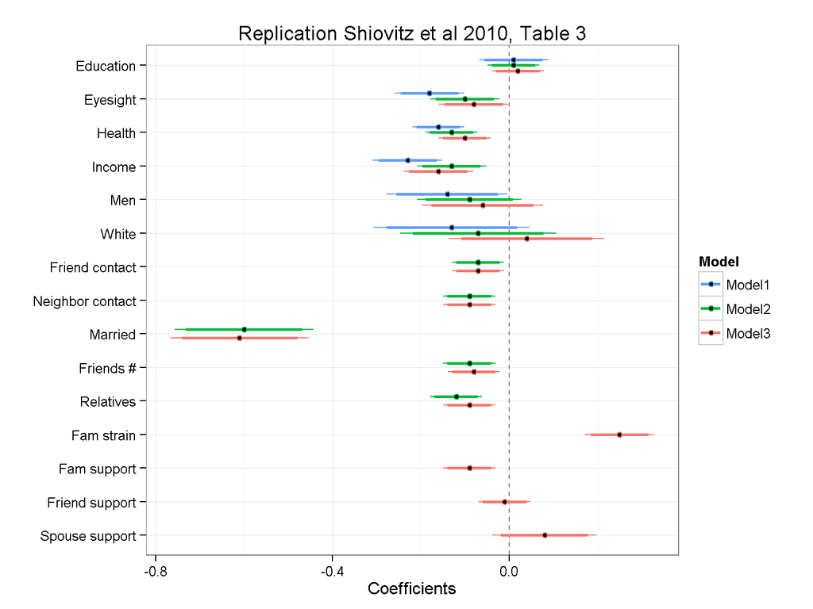

# Graphing Model Results

## What if we had more information than what was available in peer-reviewed journals?

## Consider this basic algorithm

1. Choose a predictor of interest $x_c$.
2. Estimate a model to get a vector of parameters $\hat{\boldsymbol\beta}$ and the associated variance-covariance matrix, $\hat{\boldsymbol V}$.
3. Draw several $\tilde{\boldsymbol\beta}$ from $\mathcal{N}(\hat{\boldsymbol\beta},\,\hat{\boldsymbol V})$, where $\mathcal{N}$ is a mulivariate normal distribution.
4. Calculate expected outcomes based on model parameters for all of your draws from $\mathcal{N}$.
5. Calculate summary statistics for each level of $x_c$.

This approach will work for most of the models that social welfare researchers tend to encounter.

# A Practical Example - Background

## Research Question

How does a child’s probability of exiting the foster care system vary by child characteristics?

## Multiple Permanency Outcomes

Requires that we estimate a mulinomial logistic regression model.

# A practical example - Choose a predictor of interest $x_c$.

## Getting Data Into R

- R can import and export spreadsheets (*.txt,* .csv) and *.RData files. Use the foriegn() library to import SPSS, Stata, and DBase formats.
- R commands to import data: read.dta(), read.spss(), read.csv(), or read.dbf().

```r
dat <- read.csv("dat.csv")
```

- To export use write.dta(), write.spss(), write.csv(), or write.dbf().

# A practical example - Some basic R commands.

- The dollar sign (`$`), brackets (`[,]`), and colons (`:`).

```r
dat$eps_rank[1:5]
```

```
## [1] 4 2 1 2 1
```

```r
dat[5,4]
```

```
## [1] 1
```

- The arrow (`<-`).

```r
dat$hi <- "hi joe"
dat$hi[1:5]
```

```
## [1] "hi joe" "hi joe" "hi joe" "hi joe" "hi joe"
```

# A practical example - Choose a predictor of interest $x_c$.

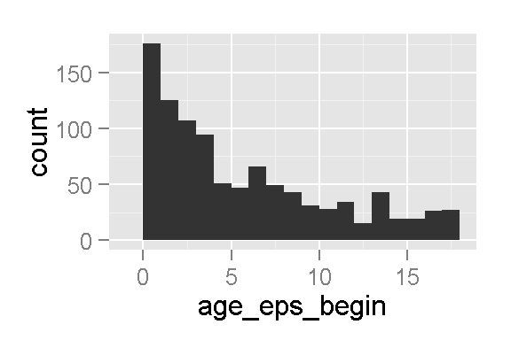

```r
#looking at age of child at episode begin
library(ggplot2)
ggplot(dat, aes(x=age_eps_begin)) +
  geom_histogram(binwidth = 1)
```

# A practical example - Choose a predictor of interest $x_c$.

## Our Predictor - Age at Episode Begin

```r
#looking at age of child at episode begin by outcome
ggplot(dat, aes(x=age_eps_begin, fill=outcome)) +
  geom_histogram(binwidth = 1) +
  facet_wrap(~ outcome) +
  xlab("Age at Episode Begin")
```

# A practical example - Choose a predictor of interest $x_c$.

## Our Predictor - Age at Episode Begin

[figure not shown]

# A practical example - Estimate a model.

## Need to estimate a statistical model to get

1. A vector of parameters $\hat{\boldsymbol\beta}$, and
2. The associated variance-covariance matrix, $\hat{\boldsymbol V}$.

# A practical example - Estimate a model.

## Prep the data

```r
# relevel our outcome variable
dat$outcome_rl <- relevel(dat$outcome
                          , ref = "Emancipation")

# recode to numeric
dat$outcome_rl <- as.numeric(dat$outcome_rl)
```

# A practical example - Estimate a model.

## Run the model

```r
# easy to load external packages
# install.packages("nnet") # install once
library(nnet)             # load every time

# run the multinomial model
model <- multinom(outcome_rl ~ age_eps_begin +
                   eps_rank
                 ,data = dat
                 ,Hess = TRUE)
```

# A practical example - Estimate a model.

## Display of summary the model

```r
model
```

```
## Call:
## multinom(formula = outcome_rl ~ age_eps_begin + eps_rank, data = dat,
##     Hess = TRUE)
##
## Coefficients:
##   (Intercept) age_eps_begin    eps_rank
## 2   11.457365    -1.0280750 -0.10995325
## 3    9.797665    -0.8393067  0.05195097
## 4   11.597181    -0.8691345  0.07149574
##
## Residual Deviance: 1720.749
## AIC: 1738.749
```

# A practical example - Estimate a model.

## Extract a vector of parameters $\hat{\boldsymbol\beta}$

```r
#run the multinomial model
model$wts
```

```
##  [1]  0.00000000  0.00000000  0.00000000  0.00000000  0.00000000
##  [6] 11.45736527 -1.02807503 -0.10995325  0.00000000  9.79766546
## [11] -0.83930667  0.05195097  0.00000000 11.59718150 -0.86913446
## [16]  0.07149574
```

```r
pe <- model$wts[c(6,7,8,10,11,12,14,15,16)]
pe[1:3]
```

```
## [1] 11.4573653 -1.0280750 -0.1099532
```

```r
pe[4:6]
```

```
## [1]  9.79766546 -0.83930667  0.05195097
```

```r
pe[7:9]
```

```
## [1] 11.59718150 -0.86913446  0.07149574
```

# A practical example - Estimate a model.

## Extract the associated variance-covariance matrix, $\hat{\boldsymbol V}$

```r
#run the multinomial model
vc <- solve(model$Hess)
```

# A practical example - Draw several $\tilde{\boldsymbol\beta}$ from $\mathcal{N}(\hat{\boldsymbol\beta},\,\hat{\boldsymbol V})$.

```r
#load a package which contains a multivariate normal
#sampling function
library(MASS)
#assign a variable for the number of simulations
sims <- 10000
#draw the indicates number of beta simulates
#using our extracted model data
simbetas <- mvrnorm(sims,pe,vc)
```

# A practical example - Last two steps…

- Calculate expected values for all of your draws from $\mathcal{N}$, and
- Calculate summary statistics for each level of $x_c$.
- Specific calculations are beyond the scope of this presentation
- But the `simcf` package from Chris Adolph (political scientist at the University of Washington) will do them for us!
- http://faculty.washington.edu/cadolph/?page=60

# A practical example - Last two steps

## Get data ready for `simcf`

- Re-arrange simulates to array format

```r
simb <- array(NA, dim = c(sims,3,3))
simb[,,1] <- simbetas[,1:3]
simb[,,2] <- simbetas[,4:6]
simb[,,3] <- simbetas[,7:9]
```

- Specify range of age values

```r
agerange <- seq(0,17,by=0.1)
```

# A practical example - Last two steps

## Get data read for `simcf`

- Load `simcf` and use the `cfFactorial()` function to set specific values for simulation.

```r
library(simcf)
xhyp <- cfFactorial(age = agerange
                    ,ep_rank = mean(dat$eps_rank))
```

- Run the simulation (this is where the last two steps are really performed).

```r
test_sims <- mlogitsimev(xhyp,simb,ci=0.95)
```

# Get the data ready to graph

```r
y <- as.vector(test_sims$pe[,1:4])

x <- rep(1:length(agerange), 4)

lower <- as.vector(test_sims$lower[,1:4,])

upper <- as.vector(test_sims$upper[,1:4,])

Outcome <- c(rep("Adoption", length(agerange))
                 ,rep("Guardianship"
                      ,length(agerange))
                 ,rep("Reunification"
                      ,length(agerange))
                 ,rep("Emancipation"
                      ,length(agerange)))
```

# Get the data ready to graph

```r
dat_sim_plot <- data.frame(y,x,lower,upper,Outcome)
```

# Graph the data!

```r
p1 <- ggplot(dat_sim_plot
       ,aes(x=x/10, y=y, group=Outcome)) +
        geom_line()
```

# Graph the data!

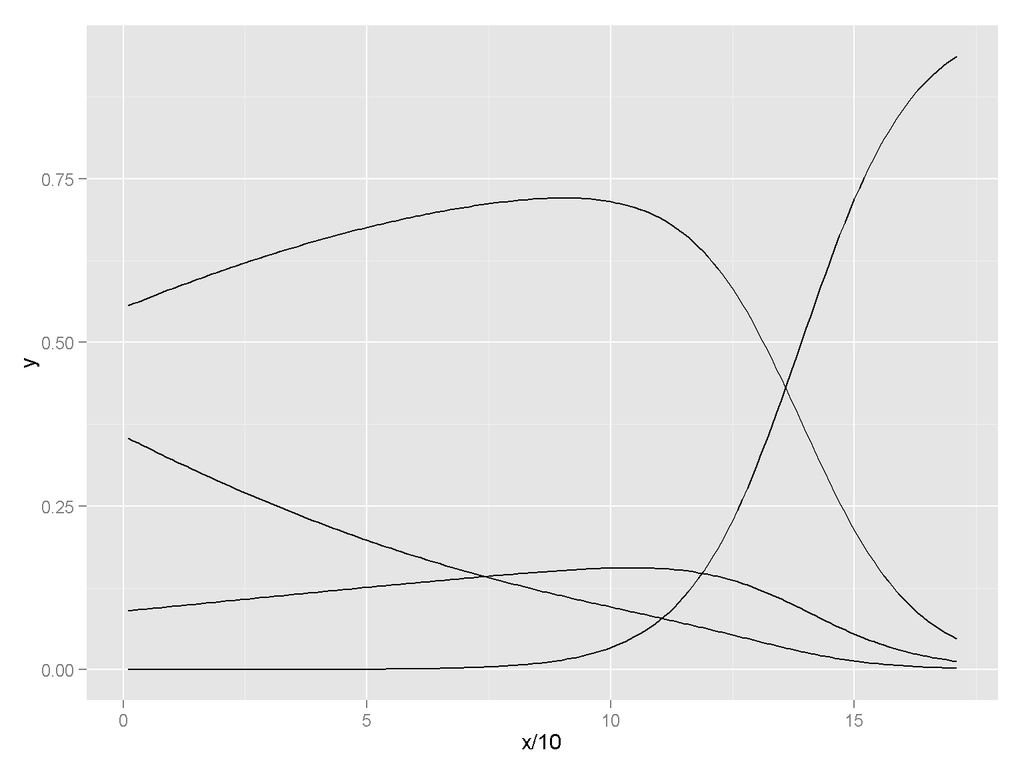

# Make it Pretty!

```r
p2 <- ggplot(dat_sim_plot
       ,aes(x=x/10, y=y, group=Outcome)) +
        geom_line(size=1, alpha=.5) +
        geom_ribbon(aes(ymin=lower
                        ,ymax=upper
                        ,fill=Outcome), alpha=.5) +
        ylab("Pr(Outcome | Age,Prior Episodes)") +
        xlab("Age at Entry into Foster Care") +
        theme_bw()
```

# Make it Pretty

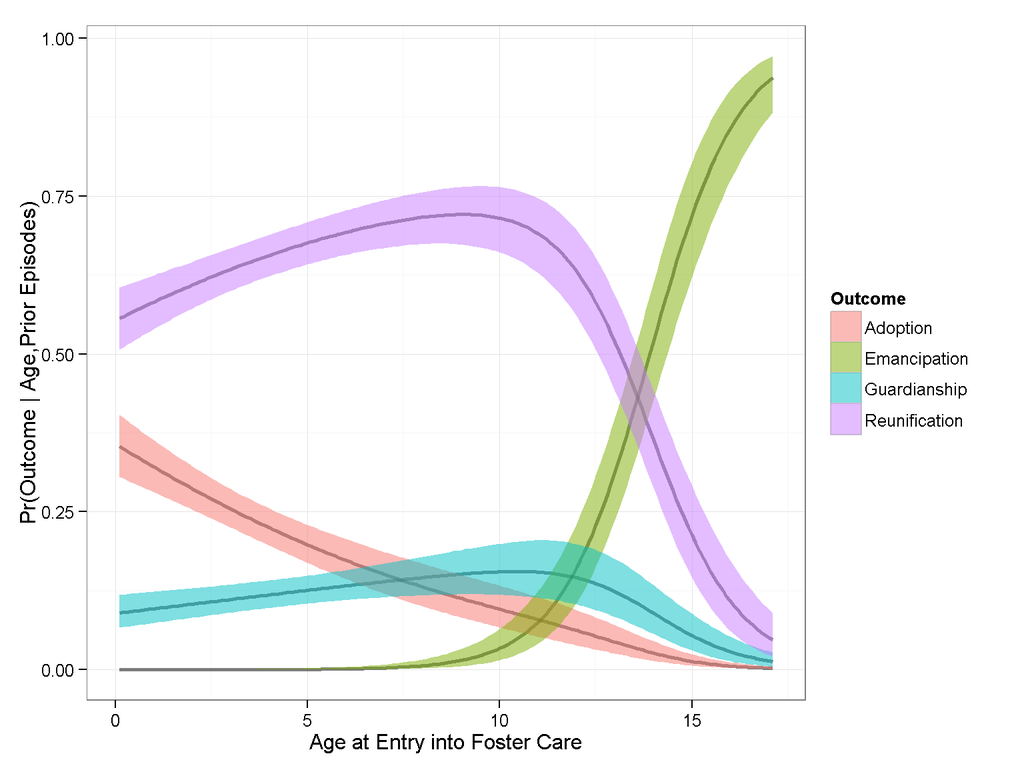

# Review of Our Steps

1. Choose a predictor of interest (we choose age at removal).
2. Estimate a model for our outcome of interest (we choose permanency outcomes using multinomial logistic regression).
3. Use the information from the model to simulate the model results using a multivariate normal distribution (we use `mvrnorm()` from the `MASS` package).
4. Calculate expected outcomes based on each set of simulated parameters (we do this with `simcf`).
5. Calculate summary statistics for each level of our predictor of interest (age) (we also do this with `simcf`).

# Some Other Examples

## Some of our blog entries.

- [Mapping Placement Mobility](http://partnersforourchildren.org/about-us/blog/family-home-foster-home-how-far-do-foster-children-move)
- [Timing of CPS Referrals](http://partnersforourchildren.org/about-us/blog/does-referral-time-matter)

## Some more `ggplot` examples.

- [`geom_smooth()`](http://docs.ggplot2.org/0.9.3.1/geom_smooth.html)
- [`geom_violin()`](http://docs.ggplot2.org/0.9.3.1/geom_violin.html)

# Moving Forward

## The Potential Future of Data Visualization

- Adding statistical model visualizations to journal websites
- Allow journal readers to choose hypothetical cases and simulate results based on statistical models

## The Near Future

- Policy simulation tools (based on the approaches outlined here) will be coming soon to the child wellbeing data portal developed by Mienko, Passolt, and others at the University of Washington during the first half of 2015.
- Check out the following url frequently for updates regarding such tools: http://partnersforourchildren.org/data-portal/

# This Presentation

## Want to replicate anything you’ve seen here?

- All of the code is available at the following repository: https://github.com/mienkoja/SSWR_R_Workshop_2015
- Fork us and try the code out for yourself!